# Red Wine Analysis

### Plot Three

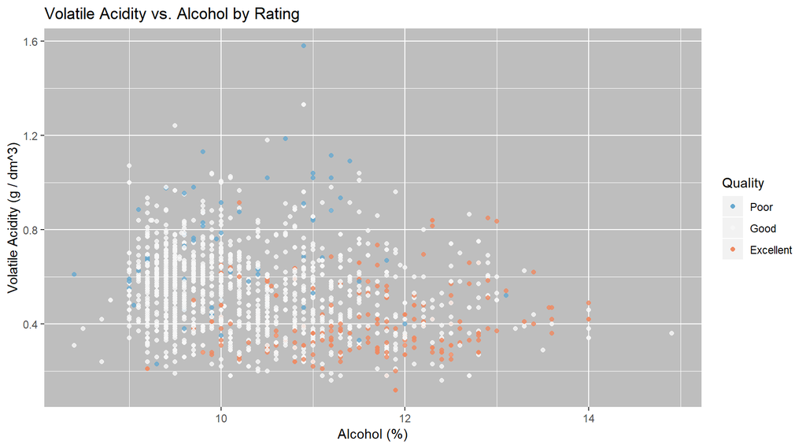

# Reflection

The red wines data set contains information on almost 1,600 red wines across t12 variables from 2009. I started by understanding the individual variables in the data set, and then I explored interesting questions and leads as I continued to make observations on plots. Eventually, I explored the wine quality and rating across many variables and tried to understand which variables created a higher quality/rating. The two variables I was able to see the strongest relationship to higher quality wines were alcohol % and volatile acidity.

What went well was that the data was tidy with no null values. I was surprised that residual sugar did not have a any relationship with quality. Prior to looking at the data I assumed that sweeter wines may have higher quality, but this was not the case.

Some of the struggles with the data set was that the quality was given in integers. To help analyze the data, I created another variable “rating” to transform this data into categorical data. Another struggle I had was that I am not familiar with chemistry so I am not truly able to fully understand some of the nuances in between the variables and their relationships to each other.

In the future it would be interesting to include price to this data set as I believe price may have a strong relationship to the quality of the wine.